# HW09: Wrangling II

Andrea Winingar

23 July 2020

Load packages.

```r
library(here)
```

source functions.

```r
source(here('Scripts', 'my_functions.R')
```

[output not shown]

### Darters in Riffles

#### Import Data

This code chunk imports the darter data. Then use filter() to remove tetrazonum and zonale.

```r
import_darter <- read_csv(here('data', 'darters.csv')) %>%
  filter(species == "blennioides" | species == "caeruleum" | species == "spectabile")
```

#### Wrangle Data

Use mutate() to sum majsub and minsub in new column called total_substrate, change riffle value 1 and 2 to riffle 1 and riffle 2. change length from cm to mm. change sex values from f and m to female and male.

| id | species | riffle | age | sex | length | depth | velocity | temperature | majsub | minsub | majtype | mintype | total_substrate |
| --- | --- | --- | --- | --- | --- | --- | --- | --- | --- | --- | --- | --- | --- |
| 1 | blennioides | riffle 1 | 0 | male | NA | 43.0 | 0.53 | 23.7 | 0.8 | 0.2 | s | c | 1 |
| 2 | blennioides | riffle 1 | 0 | male | 29 | 28.0 | 0.47 | 28.1 | 0.7 | 0.3 | c | sg | 1 |
| 3 | blennioides | riffle 1 | 1 | female | 31 | 8.0 | 0.39 | 30.2 | 0.6 | 0.4 | lg | sg | 1 |
| 4 | blennioides | riffle 1 | 1 | female | 33 | 59.0 | 0.34 | 25.4 | 0.5 | 0.5 | sg | s | 1 |
| 5 | blennioides | riffle 1 | 1 | male | 35 | 27.0 | 0.34 | 28.0 | 0.8 | 0.2 | lg | c | 1 |
| 6 | blennioides | riffle 1 | 1 | male | 36 | 7.0 | 0.36 | 24.0 | 0.6 | 0.4 | sg | lg | 1 |
| 7 | blennioides | riffle 1 | 1 | male | 37 | 13.5 | 0.61 | 29.4 | 0.6 | 0.4 | lg | sg | 1 |
| 8 | blennioides | riffle 1 | 1 | male | 37 | 27.0 | 0.34 | 28.0 | 0.5 | 0.5 | lg | sg | 1 |
| 9 | blennioides | riffle 1 | 1 | female | 38 | 11.5 | 0.34 | 30.0 | 0.6 | 0.4 | lg | sg | 1 |
| 10 | blennioides | riffle 1 | 1 | male | 38 | 12.0 | 0.39 | 29.8 | 0.6 | 0.4 | lg | sg | 1 |

[output cut: 109 more lines]

#### Summarize Data

Summarize data with group_by and summarize. summarize mean length, depth, and velocity for each species for each riffle.

| riffle | species | length | depth | velocity |
| --- | --- | --- | --- | --- |
| riffle 1 | blennioides | 34.88889 | 23.600000 | 0.4110000 |
| riffle 1 | caeruleum | 35.58974 | 22.620513 | 0.4023077 |
| riffle 1 | spectabile | 33.25926 | 15.596296 | 0.3740741 |
| riffle 2 | blennioides | 37.36842 | 19.489474 | 0.4063158 |
| riffle 2 | caeruleum | 28.07143 | 8.571429 | 0.3950000 |
| riffle 2 | spectabile | 29.10000 | 10.840000 | 0.3980000 |

#### Table results

Use kable() to make table with summary means.

| riffle | species | length | depth | velocity |
| --- | --- | --- | --- | --- |
| riffle 1 | blennioides | 34.88889 | 23.600000 | 0.4110000 |
| riffle 1 | caeruleum | 35.58974 | 22.620513 | 0.4023077 |
| riffle 1 | spectabile | 33.25926 | 15.596296 | 0.3740741 |
| riffle 2 | blennioides | 37.36842 | 19.489474 | 0.4063158 |
| riffle 2 | caeruleum | 28.07143 | 8.571429 | 0.3950000 |
| riffle 2 | spectabile | 29.10000 | 10.840000 | 0.3980000 |

#### Graph Data

Plot 1: uses stat_summary() technique x = species, y = length. add geom_point layer to add mean length of each species to the plot with filled square shape.

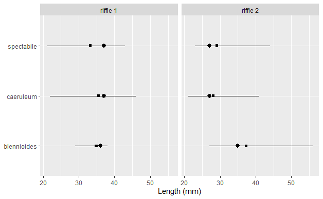

Plot 2: New plot with new geom_point layer of the length variable for each species. Change point color to gray60. add stat_summary() layer with arguments fun.y = median, geom = ‘point’, and size = 2.2. Add another stat_summary() change y function to mean, size to 3, and add color = ‘maroon’. facet, flip and label.

```
`fun.y` is deprecated. Use `fun` instead.`fun.y` is deprecated. Use `fun` instead.
```

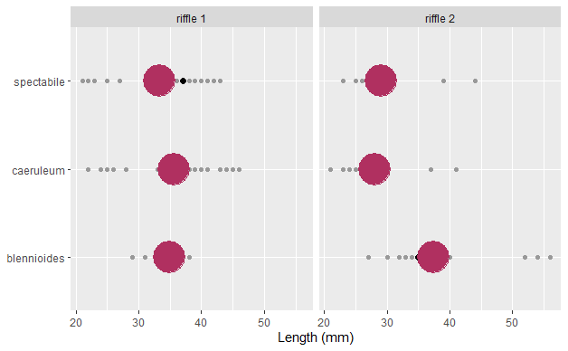

```r
darter_data %>%
  ggplot() +
  geom_point(mapping = aes(x = species, y = length), color = 'gray60') +
  stat_summary(
    mapping = aes(x = species, y = length),
    fun.y = median,
    geom = 'point',
    size = 2.2
  ) +
  stat_summary(
    mapping = aes(x = species, y = length),
    fun.y = mean,
    size = 3,
    color = "maroon"
  ) +
  facet_wrap(~ riffle) +
  coord_flip() +
  labs(x = NULL, y = 'Length (mm)')
```

### Stress and Corticosterones in birds

#### Import data

This code chunk imports data and makes necessary changes.

```r
import_feathers <- read_csv(here('data', 'feathers.csv'), locale = locale(decimal_mark = ','))
```

#### Wrangle data

| capture_date | day | site | urban_score | cortF | cortB | sex | smi | tarsus | mass | basal_court | stress_court | new_smi |
| --- | --- | --- | --- | --- | --- | --- | --- | --- | --- | --- | --- | --- |
| 25/06/2013 | 176 | CEBC | -2.50 | 66.48 | 6.32 | M | 26.1 | 18.4 | 26.7 | 1.69 | 27.76 | 26.12571 |
| 11/07/2013 | 192 | CEBC | -2.50 | 55.97 | 5.45 | F | 24.5 | 17.5 | 22.8 | 1.31 | 33.66 | 24.41717 |
| 19/07/2013 | 200 | CEBC | -2.50 | 44.96 | 4.26 | F | 25.1 | 18.4 | 25.7 | 3.27 | 17.48 | 25.14722 |
| 22/07/2013 | 203 | CEBC | -2.50 | 55.48 | 4.99 | M | 26.6 | 18.0 | 26.1 | 0.01 | 16.87 | 26.56923 |
| 22/07/2013 | 203 | CEBC | -2.50 | 62.60 | 5.41 | M | 23.9 | 18.2 | 23.9 | 0.45 | 21.45 | 23.85055 |
| 22/07/2013 | 203 | CEBC | -2.50 | 82.80 | 8.28 | M | 24.2 | 18.2 | 24.2 | 0.55 | 17.36 | 24.14993 |
| 05/08/2013 | 217 | CEBC | -2.50 | 50.62 | 4.49 | F | 26.5 | 18.1 | 26.3 | NA | 30.91 | 26.50717 |
| 05/08/2013 | 217 | CEBC | -2.50 | 35.27 | 3.17 | M | 23.7 | 18.8 | 25.2 | NA | NA | 23.72168 |
| 13/08/2013 | 225 | CEBC | -2.50 | 44.39 | 4.23 | F | 25.8 | 18.5 | 26.7 | 1.23 | 25.24 | 25.87207 |
| 13/08/2013 | 225 | CEBC | -2.50 | 45.16 | 4.75 | M | 25.7 | 18.1 | 25.5 | 0.96 | 18.12 | 25.70086 |

[output cut: 33 more lines]

#### Summarize Data

group by site and then use summarize() to calculate mean and standard error of the mean for basal_court and stress_court for each site.

| site | mean_basal | mean_stress | std_err_basal | std_err_stress |
| --- | --- | --- | --- | --- |
| CEBC | 1.108000 | 23.71455 | 0.3065319 | 1.831102 |
| LAROCHELLE | 1.731818 | 21.57923 | 0.5045463 | 1.756890 |
| NIORT | 2.160000 | 15.62800 | 0.7393691 | 1.454544 |
| VILLEFOLLET | 1.176667 | 16.95667 | 0.2893633 | 2.217938 |

#### Graph Data

Plot 1: make boxplot of new_smi for each site

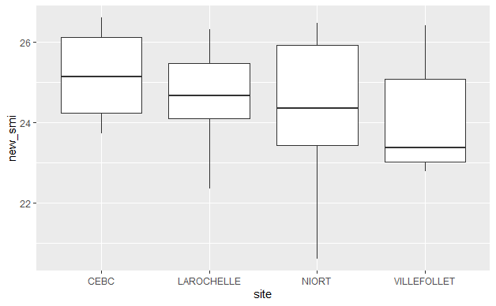

Each site has the box range after 23 smi, but there are no significant differences.

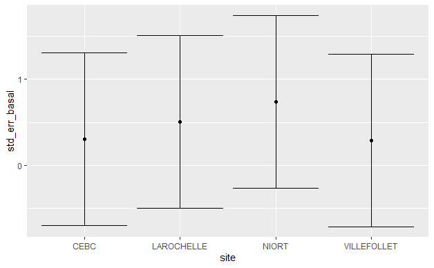

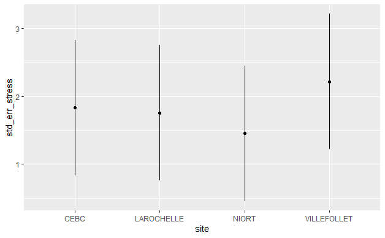